# titanic

## 导入数据

```python
#coding=utf-8
#加载项目所需库
import numpy as np
import pandas as pd

%matplotlib inline
import matplotlib.pyplot as plt
```

```python
#载入titanic数据
# PassengerId:乘客ID
# Survived:是否生还
# Pclass:乘客等级(1/2/3等舱位)
# Name:乘客姓名
# Sex:性别
# Age:年龄
# SibSp:堂兄弟/妹个数
# Parch:父母与小孩个数
# Ticket:船票信息
# Fare:票价
# Cabin:客舱
# Embarked:登船港口remote "origin"
data = pd.read_csv('titanic-data.csv')
len(data)
```

```
891
```

## 了解数据

```python
#粗略查看信息
data.info()
```

```
<class 'pandas.core.frame.DataFrame'>
RangeIndex: 891 entries, 0 to 890
Data columns (total 12 columns):
PassengerId    891 non-null int64
Survived       891 non-null int64
Pclass         891 non-null int64
Name           891 non-null object
Sex            891 non-null object
Age            714 non-null float64
SibSp          891 non-null int64
Parch          891 non-null int64
Ticket         891 non-null object
Fare           891 non-null float64
Cabin          204 non-null object
Embarked       889 non-null object
dtypes: float64(2), int64(5), object(5)
memory usage: 83.6+ KB
```

数据中有891  
Age(年龄)、Cabin(客舱)、Embarked(登船港口)信息有所缺失,其中Age、Embarked信息缺失较少,Cabin缺失严重

```python
#平均值填充Age
age_mean = data.Age.mean()
data.Age = data.Age.fillna(age_mean)
data.info()
```

```
<class 'pandas.core.frame.DataFrame'>
RangeIndex: 891 entries, 0 to 890
Data columns (total 12 columns):
PassengerId    891 non-null int64
Survived       891 non-null int64
Pclass         891 non-null int64
Name           891 non-null object
Sex            891 non-null object
Age            891 non-null float64
SibSp          891 non-null int64
Parch          891 non-null int64
Ticket         891 non-null object
Fare           891 non-null float64
Cabin          204 non-null object
Embarked       889 non-null object
dtypes: float64(2), int64(5), object(5)
memory usage: 83.6+ KB
```

```python
#众数填充Embarked
data.Embarked = data.Embarked.fillna(data.Embarked.mode().values[0])
data.info()
```

```
<class 'pandas.core.frame.DataFrame'>
RangeIndex: 891 entries, 0 to 890
Data columns (total 12 columns):
PassengerId    891 non-null int64
Survived       891 non-null int64
Pclass         891 non-null int64
Name           891 non-null object
Sex            891 non-null object
Age            891 non-null float64
SibSp          891 non-null int64
Parch          891 non-null int64
Ticket         891 non-null object
Fare           891 non-null float64
Cabin          204 non-null object
Embarked       891 non-null object
dtypes: float64(2), int64(5), object(5)
memory usage: 83.6+ KB
```

```python
#去除Cabin
data = data.dropna(axis=1, how='any')
data.info()
```

```
<class 'pandas.core.frame.DataFrame'>
RangeIndex: 891 entries, 0 to 890
Data columns (total 11 columns):
PassengerId    891 non-null int64
Survived       891 non-null int64
Pclass         891 non-null int64
Name           891 non-null object
Sex            891 non-null object
Age            891 non-null float64
SibSp          891 non-null int64
Parch          891 non-null int64
Ticket         891 non-null object
Fare           891 non-null float64
Embarked       891 non-null object
dtypes: float64(2), int64(5), object(4)
memory usage: 76.6+ KB
```

```
0    549
1    342
Name: Survived, dtype: int64
```

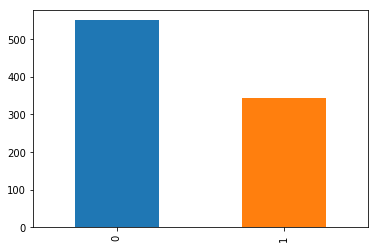

```python
#获救情况
survived_nums = data.Survived.value_counts()
print survived_nums
survived_nums.plot(kind='bar')
```

549人死亡，342人获救

```
3    491
1    216
2    184
Name: Pclass, dtype: int64
```

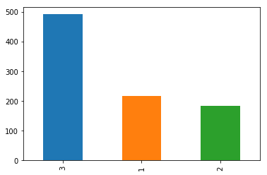

```python
#仓位
pclass_num = data.Pclass.value_counts()
print pclass_num
pclass_num.plot(kind='bar')
```

3等仓人最多491人， 2等仓人最少184人 1等仓216人

```
male      577
female    314
Name: Sex, dtype: int64
```

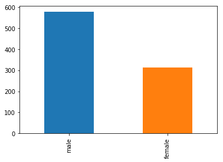

```python
#性别
sex_nums=data.Sex.value_counts()
print sex_nums
sex_nums.plot(kind='bar')
```

男性577人，女性314人 男性人数约为女性人数2倍

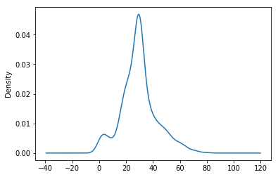

```python
#年龄
data.Age.plot(kind='kde')
```

乘客中大部分人的年龄都小于40，20到30岁之间人数最多

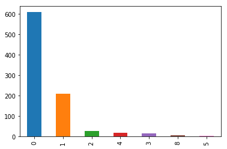

```python
#堂兄弟/妹个数
data.SibSp.value_counts().plot(kind='bar')
```

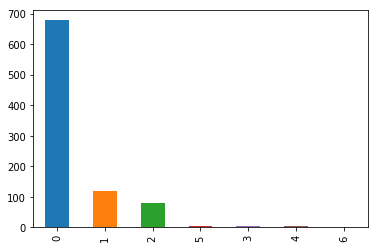

```python
# Parch:父母与小孩个数
data.Parch.value_counts().plot(kind='bar')
```

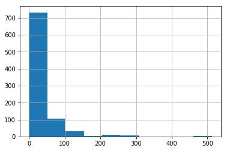

```python
# Fare:票价
data.Fare.hist(bins=10)
```

票价基本在100以内

```
S    646
C    168
Q     77
Name: Embarked, dtype: int64
```

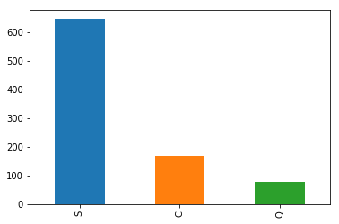

```python
# Embarked:登船港口remote "origin"
embarked_nums = data.Embarked.value_counts()
print embarked_nums
embarked_nums.plot(kind='bar')
```

S港口登船人数最多646人，元多于其他港口 Q港口人数最少77人 C港口登船人数168人

## 数据探索

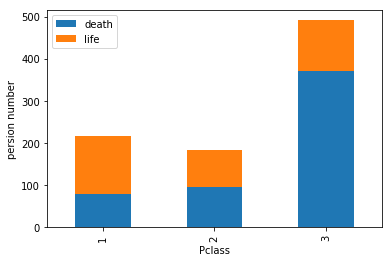

```python
#仓位与获救
Survived_0 = data.Pclass[data.Survived == 0].value_counts()
Survived_1 = data.Pclass[data.Survived == 1].value_counts()
df=pd.DataFrame({'life':Survived_1, 'death':Survived_0})
df.plot(kind='bar', stacked=True)
plt.xlabel("Pclass")
plt.ylabel("persion number")
plt.show()
```

1号仓获救几率更大些，1号仓可能为头等舱

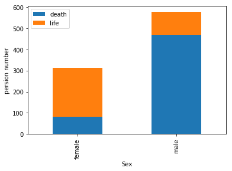

```python
#性别与获救
Survived_0 = data.Sex[data.Survived == 0].value_counts()
Survived_1 = data.Sex[data.Survived == 1].value_counts()
df=pd.DataFrame({'life':Survived_1, 'death':Survived_0})
df.plot(kind='bar', stacked=True)
plt.xlabel("Sex")
plt.ylabel("persion number")
plt.show()
```

女性获救几率远高于男性

```python
#年龄与获救
bins = np.arange(0,90,10)
data['Age_group'] = pd.cut(data['Age'],bins)
data.groupby(['Age_group'])['PassengerId'].count()
```

```
Age_group
(0, 10]      64
(10, 20]    115
(20, 30]    407
(30, 40]    155
(40, 50]     86
(50, 60]     42
(60, 70]     17
(70, 80]      5
Name: PassengerId, dtype: int64
```

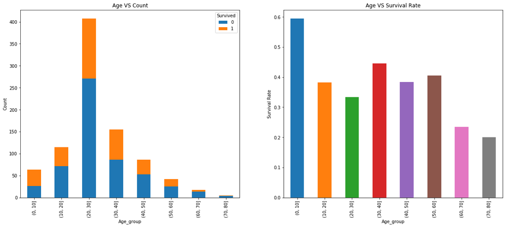

```python
plt.figure(figsize=(12,5))
f,(ax1,ax2) = plt.subplots(1,2)
f.set_size_inches((20,8))
data.groupby(['Age_group','Survived'])['PassengerId']\
    .count().unstack().plot(kind='bar',ax = ax1,stacked = True)
ax1.set_title('Age VS Count')
ax1.set_ylabel('Count')
data.groupby('Age_group')['Survived'].mean().plot(kind = 'bar',ax = ax2)
ax2.set_title('Age VS Survival Rate')
ax2.set_ylabel('Survival Rate')
plt.show()
```

0-10岁获救率最高，10-60岁之间获救率相差不大，60岁以上获救率最低

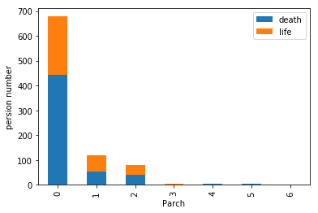

```python
# Parch:父母与小孩个数
Survived_0 = data.Parch[data.Survived == 0].value_counts()
Survived_1 = data.Parch[data.Survived == 1].value_counts()
df=pd.DataFrame({'life':Survived_1, 'death':Survived_0})
df.plot(kind='bar', stacked=True)
plt.xlabel("Parch")
plt.ylabel("persion number")
plt.show()
```

有1到3个亲人会有较大几率获救

```python
# 票价与获救
bins = np.arange(0,600,50)
data['Fare_group'] = pd.cut(data['Fare'],bins)
data.groupby(['Fare_group'])['PassengerId'].count()
```

```
Fare_group
(0, 50]       716
(50, 100]     107
(100, 150]     24
(150, 200]      9
(200, 250]     11
(250, 300]      6
(300, 350]      0
(350, 400]      0
(400, 450]      0
(450, 500]      0
(500, 550]      3
Name: PassengerId, dtype: int64
```

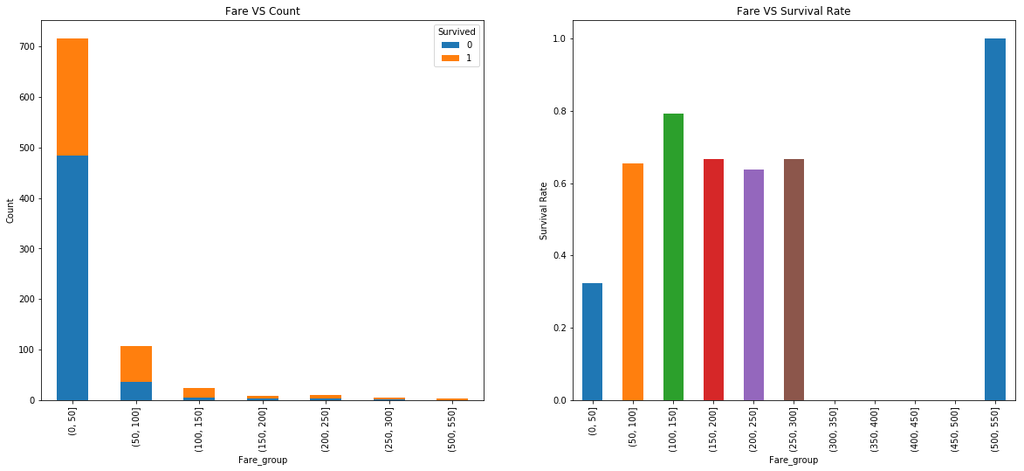

```python
plt.figure(figsize=(12,5))
f,(ax1,ax2) = plt.subplots(1,2)
f.set_size_inches((20,8))
data.groupby(['Fare_group','Survived'])['PassengerId']\
    .count().unstack().plot(kind='bar',ax = ax1,stacked = True)
ax1.set_title('Fare VS Count')
ax1.set_ylabel('Count')
data.groupby('Fare_group')['Survived'].mean().plot(kind = 'bar',ax = ax2)
ax2.set_title('Fare VS Survival Rate')
ax2.set_ylabel('Survival Rate')
plt.show()
```

票价高获救几率会大一些，富人更可能获救

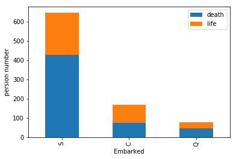

```python
#登船港口与获救
Survived_0 = data.Embarked[data.Survived == 0].value_counts()
Survived_1 = data.Embarked[data.Survived == 1].value_counts()
df=pd.DataFrame({'life':Survived_1, 'death':Survived_0})
df.plot(kind='bar', stacked=True)
plt.xlabel("Embarked")
plt.ylabel("persion number")
plt.show()
```

C港口登船的获救几率远大于S港口登船

# 结论

泰坦尼克号出事载客量2224人，报告中使用了其中部分数据891人约为总人数的40%，大体上可以代表泰坦尼克号上的整体人口，但不能完全代表。在数据清洗时，Age的填充可能会改变20-30岁的获救率和年龄的分布，Embarked的填充可能会改变S港口的获救率。朋友的个数，遇难前是在睡觉还是清醒状态，身体是否有残疾也会影响存活率